Article Classification

Jiahui Li

# Introduction

The data is a reuters data folder with 21 sgm files and each one has 1,000 articles' information in it, so there are 21,000 articles for us to build the classification model.

The response variable is the topic of the articles, with three categories, representing if the topic is 'earn', 'acq', or another category.

Our goal is to train a model to classify which topic does the article belong to.

# Text Data Import and Cleaning

```python
from lxml import html, etree
import pandas as pd
from sklearn.feature_extraction.text import TfidfVectorizer
from sklearn.svm import SVC
from sklearn.metrics import roc_curve,auc
from sklearn.metrics import precision_recall_curve
from sklearn.metrics import average_precision_score
```

```python
import nltk
#nltk.download()
# Download Corpora -> stopwords, Models -> punkt

from nltk.corpus import stopwords
from nltk.tokenize import word_tokenize
```

```python
def parse_reu(reu):
    """Parses the etree object and returns a list of dictionary of reuters attr
    Output: {'topics': the topic of the article, 'places': where it is located,
        'split': training/test split, 'body':the text of the article as a set of words with stopwords removed}
    """
    root= reu.getroot()
    articles = root.body.getchildren()
    stop_words = set(stopwords.words('english'))
    reu_pl = []
    for a in articles:
        reu_parse = {}
        if a.attrib['topics'] != 'YES':
            next
        topics = a.find('topics').findall('d')
        if topics:
            reu_parse['topics'] = [t.text for t in topics]
        else:
            reu_parse['topics'] = []
        places = a.find('places').findall('d')
        #if places:
        reu_parse['places'] = [t.text for t in places]
        reu_parse['split'] = a.attrib['lewissplit']
        rtxt = a.find('text')
        word_tokens = word_tokenize(rtxt.text_content())
        filtered_sentence = set([w.lower() for w in word_tokens if not w in stop_words])
        reu_parse['body'] = filtered_sentence
        reu_pl.append(reu_parse)
    return reu_pl
```

```python
ind = ['00'+ str(i) for i in range(10)]+['0'+str(i) for i in range(10,22)]
topics,split,body,places = [],[],[],[]

for i in ind:
    address  = "reuters/reut2-"+ i + ".sgm"
    reu = html.parse(address)
    reu_pl = parse_reu(reu)
    N = len(reu_pl)
    topics = topics + [reu_pl[i]['topics'] for i in range(N)]
    split = split + [reu_pl[i]['split'] for i in range(N)]
    body = body + [" ".join(reu_pl[i]['body']) for i in range(N)]
    places = places + [" ".join(reu_pl[i]['places']) for i in range(N)]
```

```python
df = pd.DataFrame({'topics':topics,'split':split,'body':body,'places':places})
df.head()
```

|  | body | places | split | topics |
| --- | --- | --- | --- | --- |
| 0 | july good figures doubt 995 would 785 rose lev... | el-salvador usa uruguay | TRAIN | [cocoa] |
| 1 | the north oversight interest manage investment... | usa | TRAIN | [] |
| 2 | the banking commerce 31 texas comptroller curr... | usa | TRAIN | [] |
| 3 | pressure nevertheless leading stands vice woul... | usa brazil | TRAIN | [] |
| 4 | 2.65 oct july 1984 5/14/82 reflects 1.24 7/1/8... | usa | TRAIN | [grain, wheat, corn, barley, oat, sorghum] |

```python
# construct response:
# if the topic contains 'earn', response = 0
# if the topic contains 'acq', response =1
# if the topic is another category, reponse =2
df['response'] = None
for i in range(len(df)):
    if 'earn' in df['topics'][i]:
        df['response'][i] = 'earn'
    elif 'acq' in df['topics'][i]:
        df['response'][i] = 'acq'
    else:
        df['response'][i] ='other'
```

```python
train = df[df['split']=='TRAIN']
test = df[df['split']=='TEST']
```

```python
train.shape
```

```
(14668, 5)
```

```python
test.shape
```

```
(6188, 5)
```

# Article Similarity Calculation: TF_IDF

```python
train_body = list(train['body'])
whole_body = list(df['body'])

tf_idf_whole = TfidfVectorizer().fit_transform(whole_body)
tf_idf_test = tf_idf_whole[test.index]
tf_idf_train = tf_idf_whole[train.index]
```

# SVM with Kernel PCA

```python
def roc_pr(test_ifearn, earn_score):
    fpr,tpr,threshold = roc_curve(test_ifearn, earn_score,pos_label=1)
    roc_auc = auc(fpr,tpr)
    lw = 2

    plt.figure(figsize = (15,8))
    plt.subplot(121)
    plt.plot(fpr, tpr, color='darkorange',  lw=lw, label='ROC curve (area = %0.3f)' % roc_auc)
    plt.plot([0, 1], [0, 1], color='navy', lw=lw, linestyle='--')
    plt.xlim([0.0, 1.0])
    plt.ylim([0.0, 1.05])
    plt.xlabel('False Positive Rate')
    plt.ylabel('True Positive Rate')
    plt.title('ROC for Precomputed Kernel')
    plt.legend(loc="lower right")

    precision, recall, thresholds = precision_recall_curve(test_ifearn, earn_score,pos_label=1)
    average_precision = average_precision_score(test_ifearn, earn_score)

    plt.subplot(122)
    plt.step(recall, precision, color='b', alpha=0.2,where='post')
    plt.fill_between(recall, precision, step='post', alpha=0.2,color='b')
    plt.xlabel('Recall')
    plt.ylabel('Precision')
    plt.ylim([0.0, 1.05])
    plt.xlim([0.0, 1.0])
    plt.title('PR curve for Precomputed Kernel: AP={0:0.3f}'.format(average_precision))
```

## Precomputed Kernel

### Without Place Information

Construct model by myself.

```python
fit_mat = (tf_idf_train * tf_idf_train.T).A
predict_mat = (tf_idf_test * tf_idf_train.T).A
```

```python
svc = SVC(kernel = 'precomputed',probability = True,random_state = 7)
svc.fit(fit_mat, train['response'])
pre = svc.predict_proba(predict_mat)
pre
```

```
array([[6.50394684e-03, 2.17417985e-02, 9.71754255e-01],
       [1.42759769e-02, 1.27112484e-03, 9.84452898e-01],
       [6.97988181e-03, 1.65291096e-03, 9.91367207e-01],
       ...,
       [1.54053641e-02, 5.09337656e-03, 9.79501259e-01],
       [2.35957001e-03, 1.82125843e-02, 9.79427846e-01],
       [8.29765464e-07, 5.17248894e-07, 9.99998653e-01]])
```

```python
test_ifearn = np.array([0]*test.shape[0])
test_ifearn[test['response']=='earn']=1

earn_score = pre[:,1]
```

```
Text(0.5,1,'PR curve for Precomputed Kernel: AP=0.703')
```

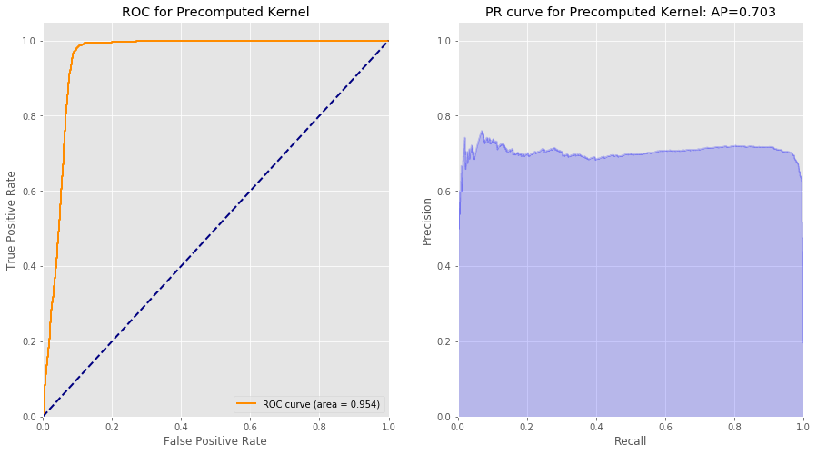

```python
roc_pr(test_ifearn, earn_score)
```

### Including Places

```python
whole_place = list(df['places'])

tf_idf_place_whole = TfidfVectorizer().fit_transform(whole_place)

tf_idf_place_test = tf_idf_place_whole[test.index]
tf_idf_place_train = tf_idf_place_whole[train.index]

place_fit_mat = (tf_idf_place_train * tf_idf_place_train.T).A
place_predict_mat = (tf_idf_place_test * tf_idf_place_train.T).A

fit_mat2 = fit_mat + place_fit_mat
predict_mat2 = predict_mat + place_predict_mat

svc2 = SVC(kernel = 'precomputed',probability = True,random_state = 7)
svc2.fit(fit_mat2, train['response'])
pre2 = svc2.predict_proba(predict_mat2)

earn_score2 = pre2[:,1]
```

```
Text(0.5,1,'PR curve for Precomputed Kernel including places: AP=0.726')
```

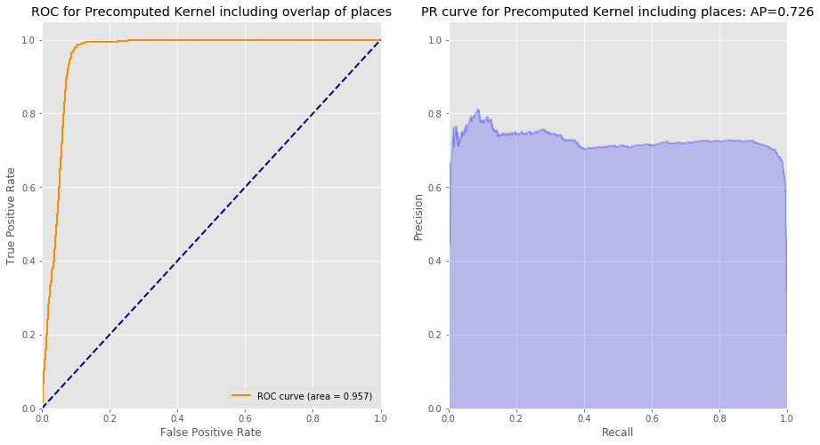

```python
roc_pr(test_ifearn, earn_score2)
```

## Linear Kernel

```python
svc_lin = SVC(kernel = 'linear',probability = True,random_state = 7)
svc_lin.fit(tf_idf_train, train['response'])
pre_lin = svc_lin.predict_proba(tf_idf_test)

earn_score_lin = pre_lin[:,1]
```

```
Text(0.5,1,'PR curve for Linear Kernel: AP=0.703')
```

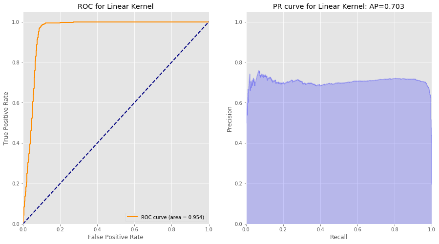

```python
roc_pr(test_ifearn, earn_score_lin)
```

## Quadratic Kernel

```python
svc_qua = SVC(kernel = 'poly',degree = 2, probability = True,random_state = 7)
svc_qua.fit(tf_idf_train, train['response'])
pre_qua = svc_qua.predict_proba(tf_idf_test)

earn_score_qua = pre_qua[:,1]
```

```
Text(0.5,1,'PR curve for Precomputed Kernel: AP=0.818')
```

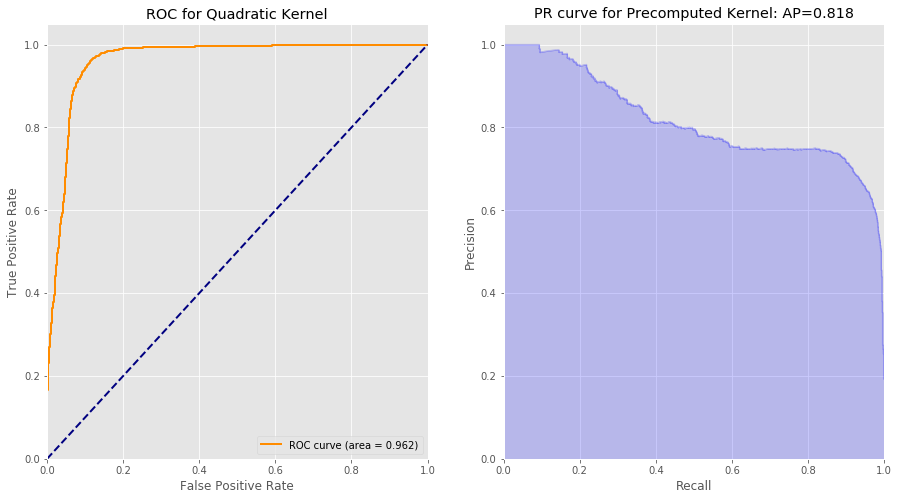

```python
roc_pr(test_ifearn, earn_score_qua)
```

## Cubic Kernel

```python
svc_cub = SVC(kernel = 'poly',degree = 3, probability = True,random_state = 7)
svc_cub.fit(tf_idf_train, train['response'])
pre_cub = svc_cub.predict_proba(tf_idf_test)

earn_score_cub = pre_cub[:,1]
```

```
Text(0.5,1,'PR curve for Cubic Kernel: AP=0.786')
```

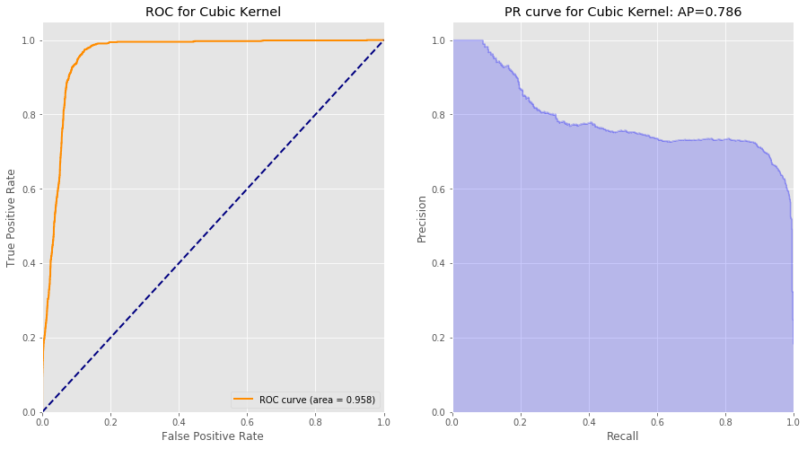

```python
roc_pr(test_ifearn, earn_score_cub)
```

## rbf Kernel

```python
svc_rbf = SVC(kernel = 'rbf', probability = True,random_state = 7)
svc_rbf.fit(tf_idf_train, train['response'])
pre_rbf = svc_rbf.predict_proba(tf_idf_test)

earn_score_rbf = pre_rbf[:,1]
```

```
Text(0.5,1,'PR curve for rbf Kernel: AP=0.829')
```

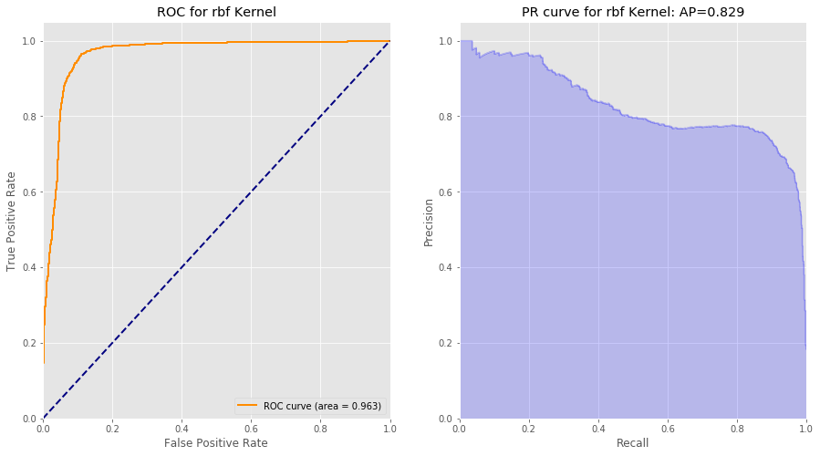

```python
roc_pr(test_ifearn, earn_score_rbf)
```

## Sigmoid Kernel

```python
svc_sig = SVC(kernel = 'sigmoid', probability = True,random_state = 7)
svc_sig.fit(tf_idf_train, train['response'])
pre_sig = svc_sig.predict_proba(tf_idf_test)

earn_score_sig = pre_sig[:,1]
```

```
Text(0.5,1,'PR curve for Sigmoid Kernel: AP=0.833')
```

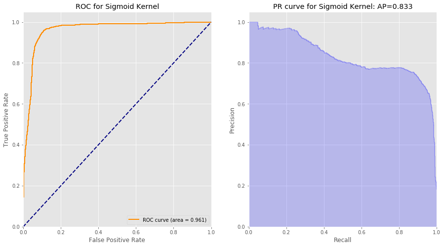

```python
roc_pr(test_ifearn, earn_score_sig)
```

# Conclusion

- With the kernel matrix based on the overlap of words, which is calculated by tf-idf, we can predict 'earn' with AUC = 0.954, and AP(average precision) = 0.703.
- Including the overlap of places into the kernel matrix, the AUC of prediction is 0.957 and AP is 0.726. Both AUC and AP are larger than those of prediction with kernel matrix only including overlap of body, so include the information of the places can make the prediction better.
- Then we also try the linear, quadratic, cubic, rbf and sigmoid kernel. The corresponding AUC and AP are showed below:

| Kernel | AUC | AP |
| --- | --- | --- |
| Precomputed | 0.954 | 0.703 |
| Linear | 0.954 | 0.703 |
| Quadratic | 0.962 | 0.818 |
| Cubic | 0.958 | 0.786 |
| Rbf | 0.963 | 0.829 |
| Sigmoid | 0.961 | 0.833 |

We can find that

- The linear kernel is the same as our precomputed one.
- The quadratic kernel is much better then the linear one, but the cubic model is worse than the quadratic one. So for the polynomial kernel, finding a proper degree is important.
- The Rbf kernel is the one with largest AUC, which is 0.963, and its AP is 0.829.
- The Sigmoid kernel is the one with largest AP, which is 0.833, and its AUC is 0.961.
- From the AUC's and AP's, I think the Rbf kernel may be the best.